# 11-Altri-Tipi-di-Entropia

## Nozioni matematiche preliminari

1. **Probabilità marginale** $$ p(x) = \sum_{y \in Y} p(x,y) $$
2. **Probabilità condizionata** $$ \begin{align} p(y|x) = \frac{p(x,y)}{p(x)} \quad p(x) > 0\\ \\ p(x|y) = \frac{p(x,y)}{p(y)} \quad p(x) > 0 \end{align} $$

Abbiamo definito l'entropia su una singola variabile aleatoria, ma possiamo **estendere** questo concetto ad una **coppia di variabili aleatorie**. Definiamo **l'entropia congiunta**come: $$ H_D(X,Y) = \sum_{x \in X} \sum_{y \in Y} p(x,y) \cdot \log_D\frac{1}{p(x,y)} $$ mentre **l'entropia condizionata** è definita come: $$ \begin{align} H(Y|X) &= \sum_{x \in X} p(x) \cdot H(Y|X = x)\quad &(1)\\ &= \sum_{x \in X}p(x) \cdot \sum_{y \in Y} p(y|x) \cdot \log \frac{1}{p(y|x)} \quad &(2)\\ &= \sum_{x \in X}\sum_{y \in Y}p(x,y)\cdot\log \frac{1}{p(y|x)} \quad &(3)\\ \end{align} $$ Nel passaggio $(2)$ si noti che $p(x) \cdot p(y|x) = p(x,y)$.

*Semanticamente*: **l'entropia condizionata** indica la quantità di informazione media che serve per comunicare un messaggio estratto da $Y$ sapendo che ho già mandato un messaggio estratto da $X$, mentre **l'entropia congiunta** indica la quantità di informazione che mi serve per descrivere due estrazioni da $X$ e $Y$.

## Chain Rule

$$ H(X,Y) = H(X) + H(Y|X) $$

### Dimostrazione

Riscriviamo $H(X,Y)$: $$ \begin{align} H(X,Y) &= \sum_{x \in X} \sum_{y \in Y} p(x,y) \cdot \log\frac{1}{p(x,y)} \quad &(1)\\ &=-\sum_{x \in X} \sum_{y \in Y} p(x,y) \cdot \log p(x,y) \quad &(2)\\ &=-\sum_{x \in X} \sum_{y \in Y} p(x,y) \cdot \log \Big[p(x)\cdot p(y|x)\Big] \quad &(3)\\ &=-\sum_{x \in X} \sum_{y \in Y} p(x,y) \cdot \log p(x) - \sum_{x \in X} \sum_{y \in Y} p(x,y) \cdot \log p(y|x) \quad &(4)\\ &=-\sum_{x \in X} p(x) \cdot \log p(x) - \sum_{x \in X} \sum_{y \in Y} p(x,y) \cdot \log p(y|x) \quad &(5)\\ &=H(X) + H(Y|X) \quad &(6)\\ \end{align} $$ Nel punto $(4)$ ho utilizzato le proprietà dei logaritmi e si noti che $\sum_{y \in Y} p(x,y)$$\cdot \log p(x)$ è la probabilità marginale $p(x)$.

Come corollario possiamo scrivere la **Chain rule** su uno spazio condizionato: $$ H(X,Y|Z) = H(X|Z) + H(Y|X,Z) $$

## Informazione Mutua

Siano due variabili aleatorie $X$ e $Y$ con funzione di massa di probabilità congiunta $p(x,y)$ e funzioni di massa marginali $p(x)$ e $p(y)$. L’informazione mutua $I(X;Y)$ è l’entropia relativa tra la distribuzione congiunta e la distribuzione prodotto $p(x)\cdot p(y)$: $$ I(X;Y) = \sum_{x \in X}\sum_{y \in Y} p(x,y) \cdot \log \frac{p(x,y)}{p(x)\cdot p(y)} $$ La relazione che lega l'**informazione mutua** con l'**entropia** è data da: $$ \begin{align} I(X;Y) = H(X) - H(X|Y) \end{align} $$

*Semanticamente:* l'informazione mutua quantifica, in media, la dipendenza tra la distribuzione congiunta di $X$ e $Y$ si discosta da quella che si otterrebbe se $X$ e $Y$ fossero **indipendenti**. Difatti se $X,Y$ sono **indipendenti** l'informazione mutua sarebbe pari $I(X;Y) = 0$ perchè sapere $Y$ non ci da nessuna informazione sulla variabile $X$. Un'altro modo di vederlo è che L'informazione mutua $I(X;Y)$ è la riduzione dell'incertezza su $X$ dovuta alla conoscenza di $Y$.

### Dimostrazione

Per definizione sappiamo che $$ \begin{align} I(X;Y) &= \sum_{x \in X}\sum_{y \in Y} p(x,y) \cdot \log \frac{p(x,y)}{p(x)\cdot p(y)}\quad &(1)\\ &= \sum_{x \in X}\sum_{y \in Y} p(x,y) \cdot \log \frac{p(y)\cdot p(x|y)}{p(x)\cdot p(y)} \quad &(2)\\ &= \sum_{x \in X}\sum_{y \in Y} p(x,y) \cdot \log \frac{p(x|y)}{p(x)} \quad &(3)\\ &= -\sum_{x \in X}\sum_{y \in Y} p(x,y) \cdot \log p(x|y)\cdot p(x) \quad &(4)\\ &= -\sum_{x \in X}\sum_{y \in Y} p(x,y) \cdot \log p(x) + \sum_{x \in X}\sum_{y \in Y} p(x,y) \cdot \log p(x|y) \quad &(5)\\ &= -\sum_{x \in X}\sum_{y \in Y} p(x,y) \cdot \log p(x) - \Big(-\sum_{x \in X}\sum_{y \in Y} p(x,y) \cdot \log p(x|y) \Big) \quad &(6)\\ &= -\sum_{x \in X} p(x) \cdot \log p(x) - \Big(-\sum_{x \in X}\sum_{y \in Y} p(x,y) \cdot \log p(x|y) \Big) \quad &(7)\\ &= H(X) - H(X|Y) \quad &(8)\\ \end{align} $$

Applicando la **Chain rule** possiamo ottenere delle espressioni equivalenti

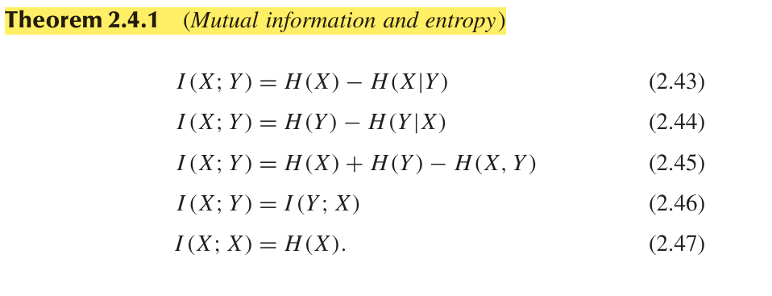

Anche **l'informazione mutua** possiamo vederla su uno spazio condizionato tale per cui: $$ I(X,Y|Z) = \sum_{x}\sum_{y}\sum_{z} p(x,y,z) \cdot \log \frac{p(x,y|z)}{p(x|z)\cdot p(y|z)} $$

## Data Processing Inequality

Siano $X,Y,Z$ variabili aleatorie con condominio finito e che la loro distribuzione congiunta $p(x,y,z)$ soddisfa $p(x,z|y) = p(x|y) \cdot p(z|y)$ allora **l'informazione mutua** $I(X,Y) \geq I(X,Z)$

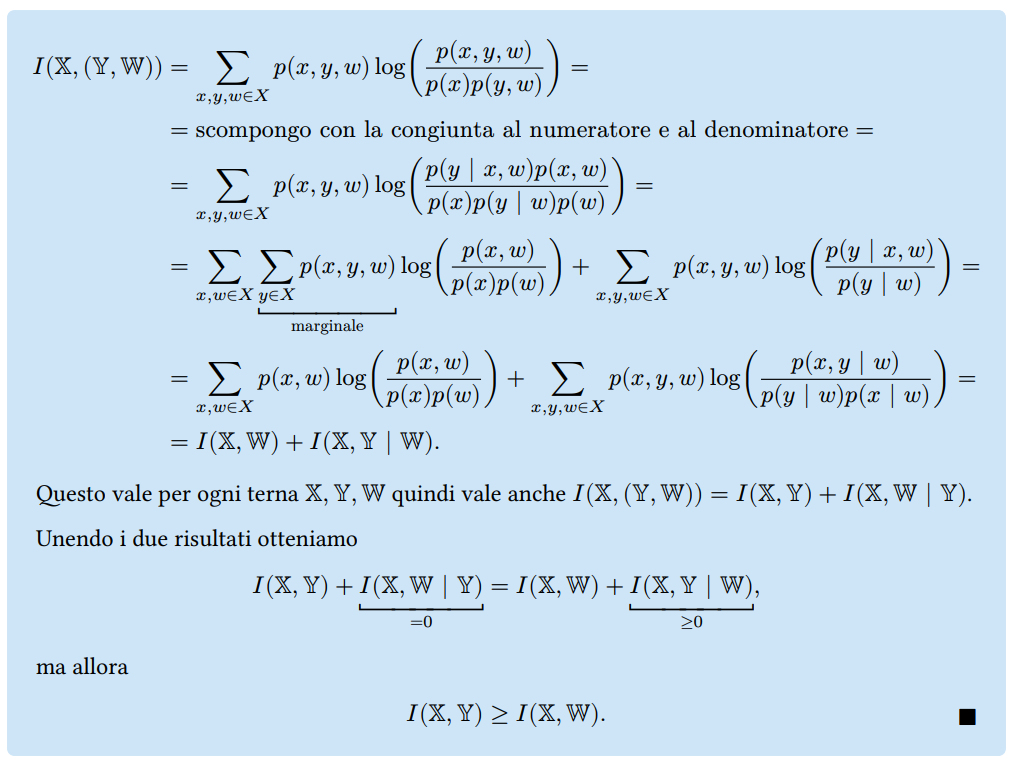

*Semanticamente*: questa disuguaglianza ci sta dicendo che se noi abbiamo questa catena $X \rightarrow Y \rightarrow Z$ se ottengo $Z$ grazie a $Y$ allora $Z$ non può contenere più informazione rispetto a $X$ (l'informazione inviata su un canale non può essere maggiore del dato originale).